# Análise de Componentes Principais

## Introdução

Um problema central na análise de dados multivariados é a **redução da dimensionalidade:** é possível descrever com precisão a informação contida nos dados mensurados em $p$ variáveis utilizando um conjunto $r < p$ de novas variáveis, perdendo a menor quantidade de informação possível?

A **análise de componentes principais** tem este objetivo: dadas $n$ observações de $p$ variáveis, se analisa se é possível representar adequadamente esta informação com um número menor de variáveis construídas como **combinações lineares** das variáveis originais.

## O Problema…

Dado um conjunto de variáveis $\mathbf{x} = [X_1 \hspace{0.1cm} X_2 \hspace{0.1cm} \cdots \hspace{0.1cm} X_p]^t$, podemos encontrar outro conjunto de variáveis $\mathbf{y} = [Y_1 \hspace{0.1cm} Y_2 \hspace{0.1cm} \cdots \hspace{0.1cm} Y_r]^t$, dadas por

$$Y_i= \displaystyle{\sum_{j=1}^p a_{ij}X_j}, \,\, i = 1, \cdots, r < p$$

de tal forma que a informação contida em $\mathbf{x}$ esteja sendo bem representada por $\mathbf{y}$?

## Algumas questões

Vamos encontrar combinações lineares para representar informação.

$$🤔 \text{O que é } \textbf{informação}?$$

**Informação $\Longrightarrow$ Variância: quanto maior a variabilidade, maior a informação contida nos dados, maior a variância dos dados**

## Algumas questões

Outra questão importante:

$$🤔 \text{O que é } \textbf{uma boa representação da informação}?$$

**Boa representação da informação $\Longrightarrow$ tomar as componentes de $\mathbf{y}$ que assegurem uma variância similar à de $\mathbf{x}$**

## Esquematicamente

Nestas condições, temos que buscar **combinações lineares** $\mathbf{y}$ das variáveis $\mathbf{x}$ de forma que se *maximize* a **variância**

$$\begin{array}{c @{\quad} c @{\quad} c}
\hline
\textbf{Variáveis Originais} & & \textbf{Combinações Lineares} \\
\hline
X_1 & & Y_1 \\
X_2 & & Y_2 \\
\vdots & & \vdots \\
X_r & \Longrightarrow & Y_r \\
\vdots & & \vdots \\
X_p & & Y_p \\
\hline
\end{array}$$

$$\large \mathrm{Var}[\mathbf{y}]:\ \text{Máxima}$$

## Esquematicamente

Ideia básica da técnica de Análise de Componentes Principais:

$$\begin{array}{c @{\quad} c @{\quad} c}
\hline
\textbf{Variáveis Originais} & & \textbf{Componentes Principais} \\
\hline
X_1 & \text{ACP} & \color{red}{Y_1} \\
X_2 & \Longrightarrow & \color{red}{Y_2} \\
\vdots & & \color{red}{\vdots} \\
X_p & & \color{red}{Y_r} \\
& & \vdots \\
& & Y_p \\
\hline
\end{array}$$

$$\scriptsize
\text{As } r \text{ primeiras componentes resumem, por exemplo, } 80\%
\text{ do comportamento geral das } p \text{ variáveis originais.}$$

## Principais objetivos

- Redução da dimensionalidade dos dados, projetando-os em uma dimensão $r < p$;

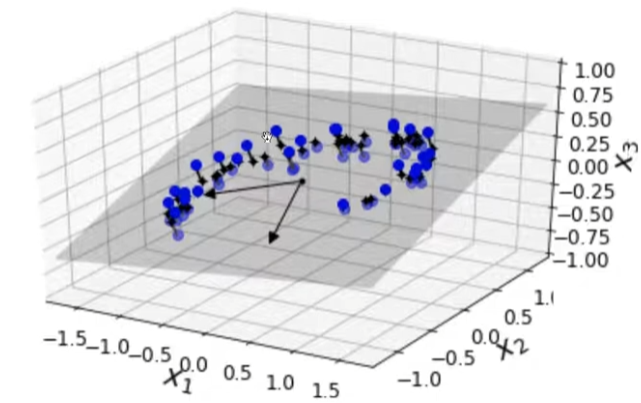

## Principais objetivos

- Obtenção de combinações interpretáveis: determinar índices e produzir escores com base nos resultados avaliados para as $p$ variáveis;

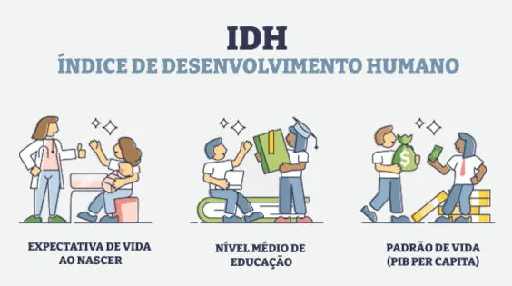

## Principais objetivos

- Descrição e entendimento da estrutura de correlação entre as variáveis, através de algumas combinações lineares das mesmas.

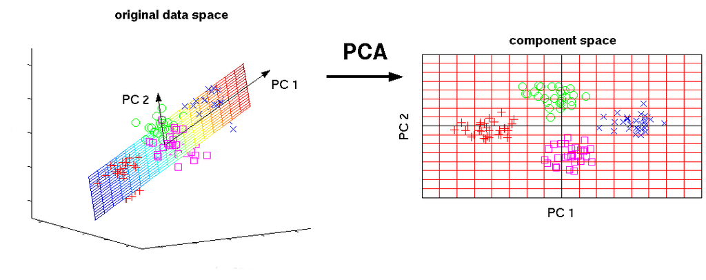

## Componentes Principais: o que são?

**Algebricamente:** são combinações lineares das $p$ variáveis originais, $X_1, X_2, \cdots, X_p$.

**Geometricamente:** são as coordenadas dos pontos amostrais em um sistema de eixos obtido pela rotação do sistema de eixos original, na direção de variabilidade máxima.

$$\Huge
\href{https://setosa.io/ev/principal-component-analysis}{\text{🔎}}$$

## Componentes Principais: alguns comentários

- Não pressupõe normalidade dos dados, embora componentes derivadas de populações normais tenham interpretações úteis.
- Com frequência, revela relações insuspeitas. Pode permitir interpretações que não seriam obtidas preliminarmente.
- Em algumas aplicações, os componentes da ACP configuram o objetivo final do estudo. Em outras, servem como passo intermediário para realização de outras análises, como regressão, classificação, agrupamento, etc…

## Componentes Principais: como obtê-los?

- Sejam $X_1, \hspace{0.1cm} X_2, \hspace{0.1cm} \cdots, \hspace{0.1cm} X_p$ as variáveis originais
- A ideia é encontrar um novo conjunto de variáveis $Y_1, \hspace{0.1cm} Y_2, \hspace{0.1cm} \cdots, \hspace{0.1cm} Y_p$, tais que:

$$\textrm{Var}[Y_1] \geqslant \textrm{Var}[Y_2] \geqslant \cdots \geqslant \textrm{Var}[Y_p]$$

- Vamos tomar cada nova variável $Y_i$, $i = 1, \cdots, p$, como uma combinação linear das variáveis originais $\mathbf{x}$:

$$Y_i = a_{i1}X_1 + a_{i2}X_2 + \cdots + a_{ip}X_p = \mathbf{a}_i^t \mathbf{x}$$

## Componentes Principais: como obtê-los?

- Para fixar problemas de escala, adicionamos uma primeira restrição aos vetores $\mathbf{a}_i$:

$$\mathbf{a}_i^t \mathbf{a}_i = \displaystyle{ \sum_{j=1}^p a_{ij}^2} = 1$$

- Para evitar que duas variáveis $Y_i$ e $Y_k$, $i \neq k$, $i,k = 1, \cdots, p$, compartilhem informação, adicionamos uma segunda restrição aos vetores $\mathbf{a}_i$:

$$\mathbf{a}_i^t \mathbf{a}_k = \displaystyle{ \sum_{j=1}^p a_{ij}a_{kj}} = 0$$

$$\textbf{💡 Garantia: }
\quad
\text{ortogonalidade, componentes não correlacionadas, independência}$$

## Componentes Principais: como obtê-los?

$${\color{red}{\Large \textbf{Primeira Componente Principal}}}$$

$$Y_1 = a_{11}X_1 + a_{12}X_2 + \cdots + a_{1p}X_p = \boldsymbol{a}_1^t \mathbf{x}$$

**Objetivo:** Encontrar $\boldsymbol{a}_1^t = [a_{11} \hspace{0.3cm} a_{12} \hspace{0.3cm} \cdots \hspace{0.3cm} a_{1p}]^t$ tal que:

$${\color{red}{ \rm{Var}[Y_1]\ \text{seja máxima}}}$$

Sujeita à restrição:

$$\boldsymbol{a}_1^t \boldsymbol{a}_1 = a_{11}^2 + a_{12}^2 + \cdots + a_{1p}^2 = 1$$

## Componentes Principais: como obtê-los?

$${\color{red}{\Large \textbf{Segunda Componente Principal}}}$$

$$Y_2 = a_{21}X_1 + a_{22}X_2 + \cdots + a_{2p}X_p = \boldsymbol{a}_2^t \mathbf{x}$$

**Objetivo:** Encontrar $\boldsymbol{a}_2^t = [a_{21} \hspace{0.3cm} a_{22} \hspace{0.3cm} \cdots \hspace{0.3cm} a_{2p}]^t$ tal que:

$${\color{red}{ \rm{Var}[Y_2]\ \text{seja máxima}}}$$

Sujeita à restrição:

$$\boldsymbol{a}_2^t \boldsymbol{a}_2 = a_{21}^2 + a_{22}^2 + \cdots + a_{2p}^2 = 1$$

$$\rm{Cov}[Y_1,Y_2] = 0$$

## Componentes Principais: como obtê-los?

$${\color{red}{\Large \textbf{i-ésima Componente Principal}}}$$

$$Y_i = a_{i1}X_1 + a_{i2}X_2 + \cdots + a_{ip}X_p = \boldsymbol{a}_i^t \mathbf{x}$$

**Objetivo:** Encontrar $\boldsymbol{a}_i^t = [a_{i1} \hspace{0.3cm} a_{i2} \hspace{0.3cm} \cdots \hspace{0.3cm} a_{ip}]^t$ tal que:

$${\color{red}{ \rm{Var}[Y_i]\ \text{seja máxima}}}$$

Sujeita à restrição:

$$\boldsymbol{a}_i^t \boldsymbol{a}_i = a_{i1}^2 + a_{i2}^2 + \cdots + a_{ip}^2 = 1$$

$$\rm{Cov}[Y_,Y_k] = 0, \text{para } k < i$$

## A escolha dos vetores $\boldsymbol{a}_i$

- Considere o vetor aleatório p-variado $\mathbf{x} = [X_1 \hspace{0.3cm} X_2 \hspace{0.3cm} \cdots \hspace{0.3cm} X_p]^t$ com vetor de médias $\boldsymbol{\mu}$ e matriz de covariâncias $\boldsymbol{\Sigma}$, positiva definida (todos os seus autovalores são positivos), sendo

$$\boldsymbol{\mu} = [\mu_1 \hspace{0.3cm} \mu_2 \hspace{0.3cm} \cdots \hspace{0.3cm} \mu_p]^t \hspace{0.5cm} \textrm{e} \hspace{0.5cm}
\boldsymbol{\Sigma} = \left[ \begin{array}{cccc} \sigma_{11} & \sigma_{12} & \cdots & \sigma_{1p}
\\ \sigma_{21} & \sigma_{22} & \cdots & \sigma_{2p}
\\ \vdots & \vdots & \ddots & \vdots
\\ \sigma_{p1} & \sigma_{p2} & \cdots & \sigma_{pp} \end{array} \right]$$

- Para determinação dos componentes principais, com base no que foi exposto, usaremos o seguinte teorema:

## A escolha dos vetores $\boldsymbol{a}_i$

**Teorema - Maximização de formas quadráticas:** Seja $\boldsymbol{B}$ uma matriz positiva definida com autovalores $\lambda_1 \geqslant \lambda_2 \geqslant \cdots \geqslant \lambda_p > 0$ e autovetores associados normalizados ${\boldsymbol{e}_1, \boldsymbol{e}_2, \cdots, \boldsymbol{e}_p}$. Então:

$$\max_{\mathbf{x} \neq \boldsymbol{0}} \dfrac{\mathbf{x}^t \boldsymbol{B} \mathbf{x}}{\mathbf{x}^t \mathbf{x}} = \lambda_1, \text{ obtido quando } \mathbf{x} = \boldsymbol{e}_1;$$

$$\min_{\mathbf{x} \neq \boldsymbol{0}} \dfrac{\mathbf{x}^t \boldsymbol{B} \mathbf{x}}{\mathbf{x}^t \mathbf{x}} = \lambda_p, \text{ obtido quando } \mathbf{x} = \boldsymbol{e}_p.$$

- Adicionalmente,

$$\max_{\mathbf{x} \perp \boldsymbol{e}_1, \boldsymbol{e}_1, \cdots, \boldsymbol{e}_k} \dfrac{\mathbf{x}^t \boldsymbol{B} \mathbf{x}}{\mathbf{x}^t \mathbf{x}} = \lambda_{k+1}, \text{ obtido quando } \mathbf{x} = \boldsymbol{e}_{k+1}.$$

## A escolha dos vetores $\boldsymbol{a}_i$

Assim, no contexto de componentes principais, seja $\mathbf{x} = [X_1 \hspace{0.3cm} X_2 \hspace{0.3cm} \cdots \hspace{0.3cm} X_p]^t$ um vetor aleatório. Seja $\boldsymbol{\Sigma}$ a matriz de variâncias e covariâncias e $(\lambda_1, \boldsymbol{e}_1)$, $(\lambda_2, \boldsymbol{e}_2)$, …, $(\lambda_p, \boldsymbol{e}_p)$ seus autovalores e autovetores, tal que $\lambda_1 \geqslant \lambda_2 \geqslant \cdots \geqslant \lambda_p > 0$. Então:

$$\max_{\boldsymbol{a} \neq \boldsymbol{0}} \dfrac{\boldsymbol{a}^t \boldsymbol{\Sigma} \boldsymbol{a}}{\boldsymbol{a}^t \boldsymbol{a}} = \max_{\boldsymbol{a} \neq \boldsymbol{0}}(\boldsymbol{a}^t \boldsymbol{\Sigma} \boldsymbol{a}) = \lambda_1, \text{ obtido quando } \boldsymbol{a} = \boldsymbol{e}_1;$$

$$\min_{\boldsymbol{a} \neq \boldsymbol{0}} \dfrac{\boldsymbol{a}^t \boldsymbol{\Sigma} \boldsymbol{a}}{\boldsymbol{a}^t \boldsymbol{a}} = \min_{\boldsymbol{a} \neq \boldsymbol{0}}(\boldsymbol{a}^t \boldsymbol{\Sigma} \boldsymbol{a}) = \lambda_p, \text{ obtido quando } \boldsymbol{a} = \boldsymbol{e}_p.$$

## A escolha dos vetores $\boldsymbol{a}_i$

- Adicionalmente,

$$\max_{\boldsymbol{a} \perp \boldsymbol{e}_1, \boldsymbol{e}_1, \cdots, \boldsymbol{e}_k} \dfrac{\boldsymbol{a}^t \boldsymbol{\Sigma} {\boldsymbol a}}{\boldsymbol{a}^t \boldsymbol{a}} = \max_{\boldsymbol{a} \perp \boldsymbol{e}_1, \boldsymbol{e}_1, \cdots, \boldsymbol{e}_k}(\boldsymbol{a}^t \boldsymbol{\Sigma} \boldsymbol{a})= \lambda_{k+1}, \text{ obtido quando } \boldsymbol{a} = \boldsymbol{e}_{k+1}.$$

## A escolha dos vetores $\boldsymbol{a}_i$

- Uma escolha interessante para os vetores de constantes ${\boldsymbol{a}_i}$, $i = 1, \cdots, p$ são os **autovetores normalizados** ${\boldsymbol{e}_i}$ da matriz $\boldsymbol{\Sigma}$.
- Dessa forma, podemos definir a $i$-ésima componente principal da matriz $\boldsymbol{\Sigma}$, $i = 1, \cdots, p$ como sendo

$$Y_i = {\boldsymbol{e}_i^t}\mathbf{x} = e_{i1}X_1 + e_{i2}X_2 + \cdots + e_{ip}X_p$$

## Componentes Principais: propriedades

- A esperança e a variância da componente $Y_i$ são respectivamente dadas por:

$$\begin{aligned}
E[Y_i]
&= E[e_{i1}X_1 + e_{i2}X_2 + \cdots + e_{ip}X_p] \\
&= e_{i1}E[X_1] + e_{i2}E[X_2] + \cdots + e_{ip}E[X_p] \\
&= e_{i1}\mu_1 + e_{i2}\mu_2 + \cdots + e_{ip}\mu_p \\
&= \boldsymbol{e}_i^{\mathsf{T}}\boldsymbol{\mu}
\end{aligned}$$

$$\textrm{Var}[Y_i] = \textrm{Var}[{\boldsymbol{e}_i^t}\mathbf{x}] = {\boldsymbol{e}_i^t} \textrm{Var}[\mathbf{x}] {\boldsymbol{e}_i}
= {\boldsymbol{e}_i^t} \boldsymbol{\Sigma} {\boldsymbol{e}_i} = {\boldsymbol{e}_i^t} \lambda_i {\boldsymbol{e}_i} =
{\boldsymbol{e}_i^t} {\boldsymbol{e}_i}\lambda_i = \lambda_i$$

## Na forma matricial

- Sejam $\boldsymbol{O}$ a matriz dos autovetores normalizados da matriz $\boldsymbol{\Sigma}$, isto é,

$$\boldsymbol{O} = \left[ \begin{array}{cccc} e_{11} & e_{21} & \cdots & e_{p1}
\\ e_{12} & e_{22} & \cdots & e_{p2}
\\ \vdots & \vdots & \ddots & \vdots
\\ e_{1p} & e_{2p} & \cdots & e_{pp} \end{array} \right] = [{\boldsymbol{e}_1} \hspace{0.5cm} {\boldsymbol{e}_2}
\hspace{0.5cm} \cdots \hspace{0.5cm} {\boldsymbol{e}_p}]$$

e $\boldsymbol{y}$ o vetor das componentes principais. Então, $\boldsymbol{y} = \boldsymbol{O}^t \mathbf{x}$ e a matriz de covariâncias de $\boldsymbol{y}$ será:

$$\textrm{Var}[\boldsymbol{y}] = \textrm{Var}[\boldsymbol{O}^t \mathbf{x}] = \boldsymbol{O}^t \textrm{Var}[\mathbf{x}] \boldsymbol{O} =
\boldsymbol{O}^t \boldsymbol{\Sigma} \boldsymbol{O} = \boldsymbol{\Lambda}$$

## Na forma matricial

sendo

$$\boldsymbol{\Lambda} = \left[ \begin{array}{cccc} \lambda_1 & 0 & \cdots & 0
\\ 0 & \lambda_2 & \cdots & 0
\\ \vdots & \vdots & \ddots & \vdots
\\ 0 & 0 & \cdots & \lambda_p \end{array} \right]$$

ou ainda, $\boldsymbol{\Sigma} = \boldsymbol{O} \boldsymbol{\Lambda} \boldsymbol{O}^t = \displaystyle \sum_{i=1}^p \lambda_i \boldsymbol{e}_i \boldsymbol{e}_i^t$, uma vez que $\boldsymbol{O}$ é uma matriz ortogonal tal que $\boldsymbol{O} \boldsymbol{O}^t = \boldsymbol{O}^t \boldsymbol{O} = \boldsymbol{I}$. Estes resultados são conhecidos como **Teorema da decomposição espectral**.

## Variabilidade explicada

$$\begin{array}{c @{\quad} c @{\quad} c @{\quad} c}
\hline
\textbf{Variável} & \textbf{Variância} & \textbf{Componente} & \textbf{Variância} \\
\hline
X_1 & \sigma_{11} & Y_1 & \lambda_1 \\
X_2 & \sigma_{22} & Y_2 & \lambda_2 \\
\vdots & \vdots & \vdots & \vdots \\
X_p & \sigma_{pp} & Y_p & \lambda_p \\
\text{Total}
& \sigma_T^2 = \displaystyle\sum_{j=1}^p \sigma_{jj} = \mathrm{tr}(\boldsymbol{\Sigma})
& \text{Total}
& \lambda_T = \displaystyle\sum_{j=1}^p \lambda_j = \mathrm{tr}(\boldsymbol{\Lambda}) \\
\hline
\end{array}$$

$$\rm{tr}(\boldsymbol{\Sigma}) = \rm{tr}(\boldsymbol{O} \boldsymbol{\Lambda} \boldsymbol{O}^t) = \rm{tr}(\boldsymbol{\Lambda} \boldsymbol{O}^t \boldsymbol{O}) = \rm{tr}(\boldsymbol{\Lambda} \boldsymbol{I}) = \rm{tr}(\boldsymbol{\Lambda})$$

$$\sigma_T^2 = \lambda_T$$

## Variabilidade explicada

- Pode-se então concluir que a **j-ésima componente explica**

$$\displaystyle{\frac{\textrm{Var}[Y_j]}{\textrm{Variância Total de X}}} = \displaystyle{\frac{\lambda_j}{\textrm{tr}(\boldsymbol{\Sigma})}} =
\displaystyle{\frac{\lambda_j}{\displaystyle{\sum_{i=1}^p \lambda_i}}}$$

da variação total original, e ainda, que as **$r$ primeiras** componentes explicam

$$\displaystyle{\frac{ \displaystyle \sum_{j=1}^r \textrm{Var}[Y_j]}{\textrm{Variância Total de X}}} = \displaystyle{\frac{\displaystyle \sum_{j=1}^r \lambda_j}{\textrm{tr}(\boldsymbol{\Sigma})}} =
\displaystyle{\frac{\displaystyle \sum_{j=1}^r \lambda_j}{\displaystyle{\sum_{i=1}^p \lambda_i}}}$$

da variação total.

## Variabilidade explicada

- Busca-se analisar um conjunto menor de variáveis sem perder muita informação sobre a estrutura de variabilidade original
- Aproximação de $\boldsymbol{\Sigma}$: Analisando as $r$ primeiras componentes principais

$$\boldsymbol{\Sigma} \approx \displaystyle \sum_{i=1}^r \lambda_i \boldsymbol{e}_i \boldsymbol{e}_i^t$$

- Cada parcela da soma envolve uma matriz de dimensão $p \times p$ correspondente apenas à informação da $j$-ésima componente principal

## Correlação com as variáveis originais

- Os coeficientes de correlação entre a $j$-ésima variável e a $i$-ésima componente principal é dada por:

$$\rho_{Y_i,X_j} = \displaystyle{\frac{e_{ij} \sqrt{\lambda_i}}{\sqrt{\sigma_{jj}}}}$$

- As correlações medem unicamente a importância de uma variável individual sem considerar a influência das demais. Não medem a importância de $X_i$ na presença de outras variáveis.
- Os coeficientes (**cargas**) dos componentes ($e_{ij}$), seus sinais e magnitudes, permitem interpretar os componentes e avaliar a importância das variáveis em sua constituição.

## Estimação das Componentes Principais

- Em geral, $\boldsymbol{\Sigma}$ é estimada por $\boldsymbol{S}$

$$\boldsymbol{S} = \left[ \begin{array}{cccc} s_{11} & s_{12} & \cdots & s_{1p}
\\ s_{21} & s_{22} & \cdots & s_{2p}
\\ \vdots & \vdots & \ddots & \vdots
\\ s_{p1} & s_{p2} & \cdots & s_{pp} \end{array} \right]$$

- Autovalores de $\boldsymbol{S}$: $\hat{\lambda}_1, \hat{\lambda}_2, \cdots, \hat{\lambda}_p$
- Autovetores de $\boldsymbol{S}$: $\hat{\boldsymbol{e}}_1, \hat{\boldsymbol{e}}_2, \cdots, \hat{\boldsymbol{e}}_p$

## Estimação das Componentes Principais

- Estimação da $j$-ésima componente principal de $\boldsymbol{S}$:

$$\hat{Y}_j = {\hat{\boldsymbol{e}}_j^t}\mathbf{x} = \hat{e}_{j1}X_1 + \hat{e}_{j2}X_2 + \cdots + \hat{e}_{jp}X_p, \,\,\,\,\,\, j = 1, 2, \cdots, p$$

- Componentes principais amostrais - Propriedades
  - Variância: $\text{Var}(\hat{Y}_j) = \hat{\lambda}_j$
  - Covariância entre as componentes: $\text{Cov}(\hat{Y}_j, \hat{Y}_k) = 0, \,\,\, j \neq k$
  - Variância total estimada explicada pela componente:
    $$\dfrac{\text{Var}(\hat{Y}_j)}{\text{Variância total estimada de } \mathbf{x}} = \dfrac{\hat{\lambda}_j}{\text{tr}(\boldsymbol{S})} = \dfrac{\hat{\lambda}_j}{\sum \limits_{i=1}^p \hat{\lambda}_i}$$

## Estimação das Componentes Principais

- Correlação estimada entre componente e variável:
  $$r_{\hat{Y}_j,\hat{X}_k} = \displaystyle{\frac{\hat{e}_{jk} \sqrt{\hat{\lambda}_j}}{\sqrt{\sigma_{kk}}}}$$
- Decomposição espectral de $\boldsymbol{S}$:

$$\boldsymbol{S} = \displaystyle \sum_{j=1}^p \hat{\lambda}_j \hat{\boldsymbol{e}}_j \hat{\boldsymbol{e}}_j^t$$

## Estimação das Componentes Principais

- Aproximação de $\boldsymbol{S}$ pelas $r$ primeiras componentes

$$\boldsymbol{S} \approx \displaystyle \sum_{j=1}^r \hat{\lambda}_j \hat{\boldsymbol{e}}_j \hat{\boldsymbol{e}}_j^t$$

- Escores das componentes
  - Valor das componentes para cada elemento amostral
  - Na prática, o uso das componentes relevantes se dá através dos escores

## Exemplo: (Mingoti,2007)

$$\small
\text{12 empresas, 3 variáveis: ganho bruto }(X_1)\text{, ganho líquido }(X_2)\text{ e patrimônio acumulado }(X_3)$$

$$\scriptsize
\begin{array}{l @{\quad} r @{\quad} r @{\quad} r}
\hline
\textbf{Empresa} &
\textbf{Ganho bruto }(X_1) &
\textbf{Ganho líquido }(X_2) &
\textbf{Patrimônio }(X_3) \\
\hline
\mathit{E1} & 9893 & 564 & 17689 \\
\mathit{E2} & 8776 & 389 & 17359 \\
\mathit{E3} & 13572 & 1103 & 18597 \\
\mathit{E4} & 6455 & 743 & 8745 \\
\mathit{E5} & 5129 & 203 & 14397 \\
\mathit{E6} & 5432 & 215 & 3467 \\
\mathit{E7} & 3807 & 385 & 4679 \\
\mathit{E8} & 3423 & 187 & 6754 \\
\mathit{E9} & 3708 & 127 & 2275 \\
\mathit{E10} & 3294 & 297 & 6754 \\
\mathit{E11} & 5433 & 432 & 5589 \\
\mathit{E12} & 6287 & 451 & 8972 \\
\hline
\end{array}$$

## Primeiro Exemplo: (Mingoti,2007)

```r
load <- function(pkg){
  new.pkg <- pkg[!(pkg %in% installed.packages()[, "Package"])]
  if (length(new.pkg))
    install.packages(new.pkg, dependencies = TRUE)
  sapply(pkg, require, character.only = TRUE)
}

## Pacotes utilizados nessa análise

packages = c("tidyverse", "factoextra", "psych", "gridExtra")
load(packages)
```

```
 tidyverse factoextra      psych  gridExtra
      TRUE       TRUE       TRUE       TRUE
```

```r
dados <- read.table("https://raw.githubusercontent.com/tiagomartin/est014/refs/heads/master/dados/empresas.txt", row.names = 1, header = TRUE)
dados %>%
  str()
```

```
'data.frame':   12 obs. of  3 variables:
 $ Granho_Bruto : int  9893 8776 13572 6455 5129 5432 3807 3423 3708 3294 ...
 $ Ganho_Liquido: int  564 389 1103 743 203 215 385 187 127 297 ...
 $ Patrimonio   : int  17689 17359 18597 8745 14397 3467 4679 6754 2275 6754 ...
```

## Primeiro Exemplo: (Mingoti,2007)

```r
x_barra = dados %>%
  colMeans()

x_barra
```

```
 Granho_Bruto Ganho_Liquido    Patrimonio
    6267.4167      424.6667     9606.4167
```

```r
S = dados %>%
  var()

S
```

```
              Granho_Bruto Ganho_Liquido Patrimonio
Granho_Bruto     9550608.6     706121.06 14978232.5
Ganho_Liquido     706121.1      76269.52   933915.1
Patrimonio      14978232.5     933915.06 34408113.0
```

## Primeiro Exemplo: (Mingoti,2007)

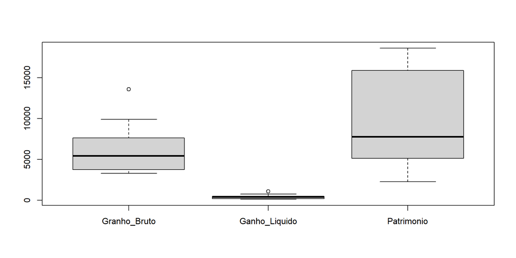

```r
dados %>%
  boxplot()
```

## Primeiro Exemplo: (Mingoti,2007)

```r
## Analise de Componentes Principais utilizando a matriz de covariancias (Nao aconselhavel, neste caso)
acp_S = prcomp(dados)

## Proporcao da variacao explicada
summary(acp_S)
```

```
Importance of components:
                             PC1       PC2       PC3
Standard deviation     6440.0615 1.594e+03 145.23266
Proportion of Variance    0.9418 5.767e-02   0.00048
Cumulative Proportion     0.9418 9.995e-01   1.00000
```

```r
## Loadings (cargas)
acp_S$rotation
```

```
                      PC1         PC2         PC3
Granho_Bruto  -0.42509725 -0.89970680 -0.09909593
Ganho_Liquido -0.02766083 -0.09651661  0.99494694
Patrimonio    -0.90472493  0.42569029  0.01614231
```

```r
## Opcional: trocar sinal da primeira componente e escores
acp_S$rotation = -acp_S$rotation
acp_S$x = -acp_S$x

## Loadings (cargas)
acp_S$rotation
```

```
                     PC1         PC2         PC3
Granho_Bruto  0.42509725  0.89970680  0.09909593
Ganho_Liquido 0.02766083  0.09651661 -0.99494694
Patrimonio    0.90472493 -0.42569029 -0.01614231
```

## Primeiro Exemplo: (Mingoti,2007)

$$Y_1 = 0,425 \times \text{GB} + 0,028 \times \text{GL} + 0,905 \times \text{PA} \Longrightarrow
94,18\% \text{ da informação total de } \mathbf{x}$$

$$\Large
\color{red}{\textbf{Qual a variável mais importante para } Y_1 \textbf{?}}$$

$$\Large
\textbf{Patrimônio}$$

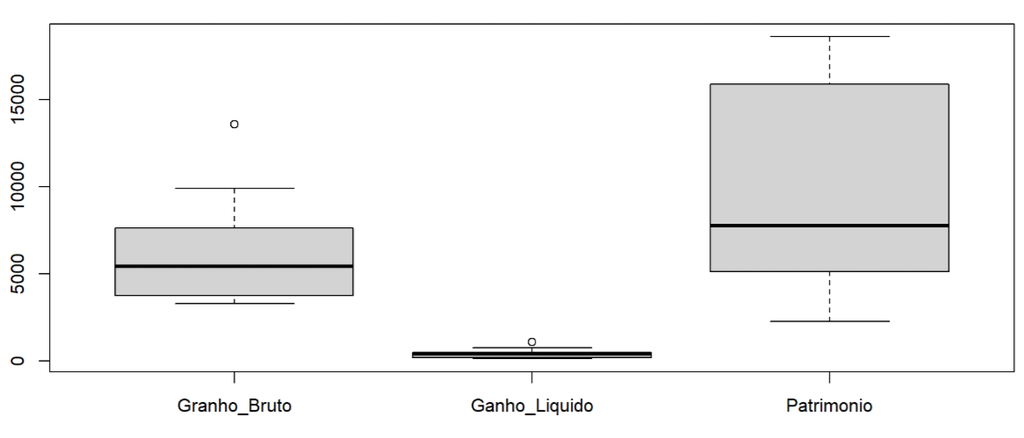

$$\Huge
\color{red}{🤔 \textbf{Será?}}$$

## Componentes Principais: variáveis padronizadas

- Padronização do vetor aleatório $\mathbf{x}$:

$$\boldsymbol{z} = \boldsymbol{D}^{-1}(\mathbf{x} - \boldsymbol{\mu})$$

- $\boldsymbol{D}$: matriz diagonal de desvios-padrão
- Variável padronizada: $Z_i = \dfrac{X_i - \mu_i}{\sqrt{\sigma_{ii}}}$
- Matriz de covariâncias de $\boldsymbol{z}$

$$\text{Cov}(\boldsymbol{z}) = \boldsymbol{D}^{-1}\boldsymbol{\Sigma} \boldsymbol{D}^{-1} = \boldsymbol{P} = \text{Cor}(\mathbf{x})$$

- Componentes principais de $\boldsymbol{z}$: obtidas dos autovalores e autovetores de $\boldsymbol{P}$

## Componentes Principais: variáveis padronizadas

- A $j$-ésima componente principal da matriz $\boldsymbol{P}$:

$$Y_j = \boldsymbol{e}_j^t \boldsymbol{z} = \boldsymbol{e}_j^t \boldsymbol{D}^{-1}(\mathbf{x} - \boldsymbol{\mu}) = {e}_{j1}Z_1 + {e}_{j2}Z_2 + \cdots + {e}_{jp}Z_p$$

sendo $\boldsymbol{e}_j$, o $j$-ésimo autovetor da matriz $\boldsymbol{P}$, $j = 1, \cdots p$.

- Variância total de $\boldsymbol{P}$

$$\sum \limits_{j=1}^p \text{Var}(Y_j) = \sum \limits_{j=1}^p \text{Var}(Z_j) = p$$

## Componentes Principais: variáveis padronizadas

- Proporção da variância populacional padronizada devido à $j$-ésima componente

$$\dfrac{\text{Var}({Y}_j)}{\text{Variância total de } \boldsymbol{z}} = \dfrac{{\lambda}_j}{\text{tr} (\boldsymbol{P})} = \dfrac{{\lambda}_j}{p}$$

- Correlação entre componente $Y_j$ e a variável padronizada $Z_k$:

$$\rho_{Y_j,Z_k} = e_{jk} \sqrt{\lambda_j}$$

## Observações

- As componentes principais **não são invariantes à mudanças de escala**. Os resultados são **diferentes** quando se faz a análise utilizando a matriz de covariâncias e a matriz de correlações.
- **As componentes obtidas a partir da matriz de covariâncias são influenciadas pelas variáveis de maior variância**. A **matriz de correlações**, em geral, é a melhor opção quando as **variâncias são muito heterogêneas**.
- Um valor **pequeno incomum** para o **último autovalor** da matriz de covariâncias (ou correlação) amostral pode indicar uma **dependência linear não detectada** no conjunto de dados.
- Valores grandes de autovalores (e correspondentes autovetores) são importantes em uma análise.

## Quantas componentes devem ser retidas?

- **Critério de Kaiser:** Trata-se de uma regra prática (heurística) para decidir quantas componentes principais manter em uma PCA extraída através da matriz de correlações. Ele diz:

> Retenha apenas as componentes associadas a um autovalor maior que 1.
- $\lambda = 1$ → a componente explica tanta variabilidade quanto 1 variável original
- $\lambda > 1$ → explica mais variabilidade do que qualquer variável isolada
- $\lambda < 1$ → explica menos variabilidade do que uma única variável → então não “vale a pena”

## Quantas componentes devem ser retidas?

- **Média dos autovalores:** É um critério alternativo quando a PCA é feita sobre **matriz de covariâncias**.

> Se PCA foi feita na matriz de covariâncias, retenha PCs com autovalores maiores que a média dos autovalores.

Então, se uma componente tem autovalor:

$$\lambda_k > \dfrac{\sum \limits_{j=1}^p \lambda_j}{p}$$

ela retém mais informação do que a variância média por dimensão do espaço original.

## Quantas componentes devem ser retidas?

- **Screeplot:** É um gráfico que coloca, no eixo X, o número da componente principal e, no eixo Y, o autovalor (ou a variância explicada).

> O ponto onde a curva deixa de cair abruptamente e começa a “horizontalizar” é onde você para de manter componentes.
- A ideia é identificar o “cotovelo” da curva.
  - antes do cotovelo: cada componente adiciona bastante variância
  - depois do cotovelo: os autovalores ficam “quase uma linha reta” → só ruído

## Quantas componentes devem ser retidas?

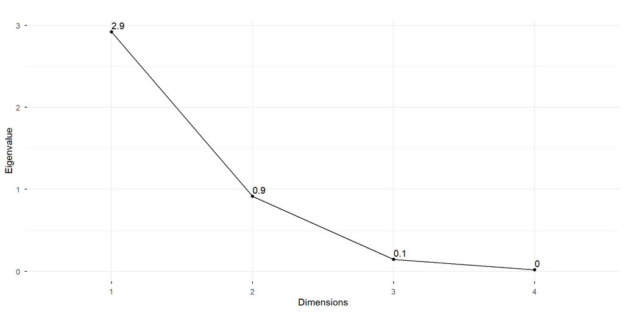

## Quantas componentes devem ser retidas?

- Reter o número de componentes principais que acumulem pelo menos certa porcentagem da variabilidade total dos dados, digamos 70%.

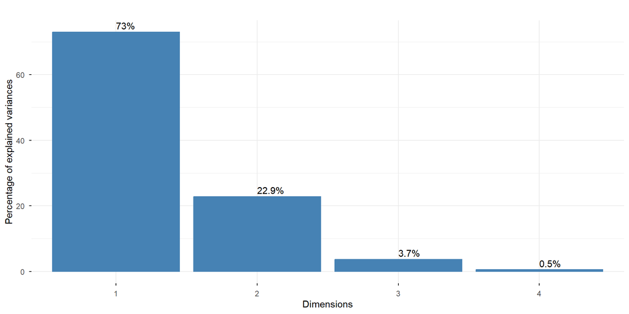

## Quantas componentes devem ser retidas?

- **Parallel Analysis (Horn, 1965):** É o método moderno mais recomendado para decidir quantos componentes reter em PCA.

> Compare seus autovalores reais com autovalores esperados ao acaso.

## Quantas componentes devem ser retidas?

- O procedimento envolve:
  - Calcular os autovalores dos dados originais.
  - Gerar dados aleatórios com a mesma estrutura dos dados originais.
  - Calcular autovalores para os dados aleatórios, repetindo o processo muitas vezes para obter uma distribuição amostral.
  - Comparar os autovalores reais com os autovalores médios ou percentis (como o 95º) dos dados simulados.
  - Reter os componentes cujos autovalores reais são maiores do que os autovalores aleatórios correspondentes.

## Quantas componentes devem ser retidas?

```
Parallel analysis suggests that the number of factors =  NA  and the number of components =  1
```

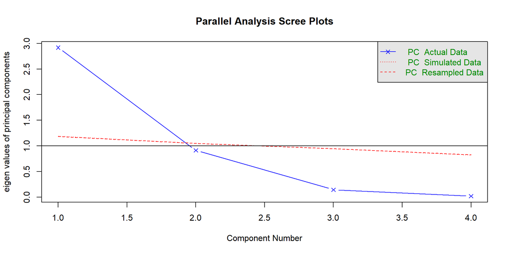

## Quantas componentes devem ser retidas?

- **Interpretação desse gráfico**
  - linha azul = autovalores reais dos seus dados
  - linhas vermelha / pontilhada = autovalores esperados pelo acaso (parallel analysis)
- **Regra:** retenha apenas os componentes cuja linha azul está acima da linha vermelha.
  - Parallel Analysis (Horn) está dizendo: retenha 1 componente principal.

## Interpretação das componentes principais

- Em geral, quando existe uma **alta correlação positiva** entre todas as variáveis, os **sinais associados às variáveis coincidem** na primeira componente principal.
- Neste caso, a primeira componente principal pode ser interpretada como um **índice global**, calculado como uma média ponderada de todas as variáveis.
- O restante das componentes, normalmente possuem **pesos negativos e positivos** e são interpretadas como um **contraste entre grupos de variáveis**.

## Voltando ao Exemplo

$$\small
\text{12 empresas, 3 variáveis: ganho bruto }(X_1)\text{, ganho líquido }(X_2)\text{ e patrimônio acumulado }(X_3)$$

$$\scriptsize
\begin{array}{l @{\quad} r @{\quad} r @{\quad} r}
\hline
\textbf{Empresa} &
\textbf{Ganho bruto }(X_1) &
\textbf{Ganho líquido }(X_2) &
\textbf{Patrimônio }(X_3) \\
\hline
\mathit{E1} & 9893 & 564 & 17689 \\
\mathit{E2} & 8776 & 389 & 17359 \\
\mathit{E3} & 13572 & 1103 & 18597 \\
\mathit{E4} & 6455 & 743 & 8745 \\
\mathit{E5} & 5129 & 203 & 14397 \\
\mathit{E6} & 5432 & 215 & 3467 \\
\mathit{E7} & 3807 & 385 & 4679 \\
\mathit{E8} & 3423 & 187 & 6754 \\
\mathit{E9} & 3708 & 127 & 2275 \\
\mathit{E10} & 3294 & 297 & 6754 \\
\mathit{E11} & 5433 & 432 & 5589 \\
\mathit{E12} & 6287 & 451 & 8972 \\
\hline
\end{array}$$

## Voltando ao Exemplo

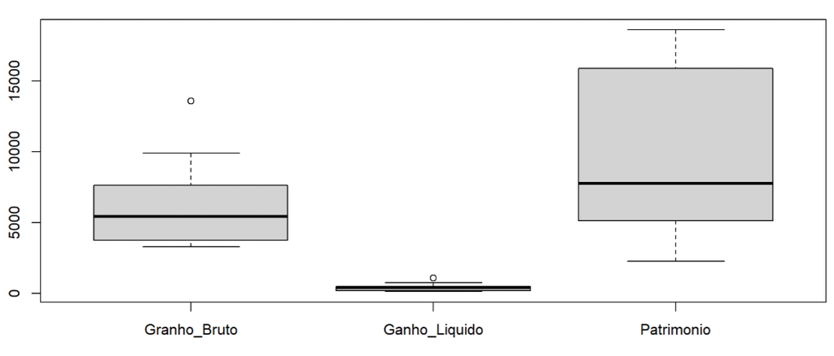

## Voltando ao Exemplo

```r
dados %>%
  scale(center=TRUE, scale=TRUE)
```

```
    Granho_Bruto Ganho_Liquido Patrimonio
E1   1.173173832    0.50452133  1.3779065
E2   0.811732638   -0.12914781  1.3216486
E3   2.363632341    2.45622228  1.5327010
E4   0.060698607    1.15267434 -0.1468530
E5  -0.368371244   -0.80264757  0.8166914
E6  -0.270325871   -0.75919598 -1.0466384
E7  -0.796146767   -0.14363167 -0.8400185
E8  -0.920402290   -0.86058304 -0.4862757
E9  -0.828181394   -1.07784103 -1.2498488
E10 -0.962144379   -0.46227672 -0.4862757
E11 -0.270002289    0.02655375 -0.6848831
E12  0.006336816    0.09535212 -0.1081544
attr(,"scaled:center")
 Granho_Bruto Ganho_Liquido    Patrimonio
    6267.4167      424.6667     9606.4167
attr(,"scaled:scale")
 Granho_Bruto Ganho_Liquido    Patrimonio
    3090.4059      276.1694     5865.8429
```

## Voltando ao Exemplo

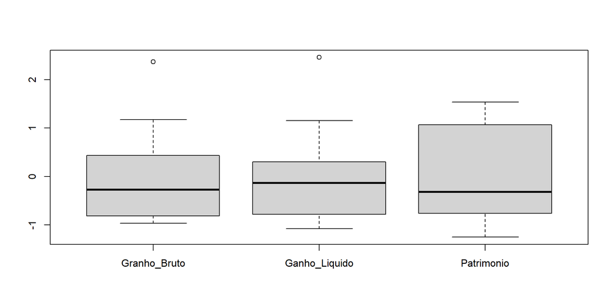

```r
dados %>%
  scale(center=TRUE, scale=TRUE) %>%
  boxplot()
```

## Voltando ao Exemplo

```r
## Analise de Componentes Principais utilizando a matriz de correlacoes (Mais aconselhavel, neste caso)
acp_R = prcomp(dados, scale. = TRUE)

## Proporcao da variacao explicada
summary(acp_R)
```

```
Importance of components:
                          PC1    PC2     PC3
Standard deviation     1.5788 0.6508 0.28978
Proportion of Variance 0.8308 0.1412 0.02799
Cumulative Proportion  0.8308 0.9720 1.00000
```

```r
## Loadings (cargas)
acp_R$rotation
```

```
                     PC1          PC2        PC3
Granho_Bruto  -0.6167027  0.001267206  0.7871952
Ganho_Liquido -0.5567945  0.706196936 -0.4373395
Patrimonio    -0.5564690 -0.708014324 -0.4348080
```

```r
## Opcional: trocar sinal da primeira componente e escores
acp_R$rotation = -acp_R$rotation
acp_R$x = -acp_R$x

## Loadings (cargas)
acp_R$rotation
```

```
                    PC1          PC2        PC3
Granho_Bruto  0.6167027 -0.001267206 -0.7871952
Ganho_Liquido 0.5567945 -0.706196936  0.4373395
Patrimonio    0.5564690  0.708014324  0.4348080
```

## Voltando ao Exemplo

```r
## Escores das componentes principais
Yr = acp_R$x
Yr %>% head()
```

```
          PC1        PC2        PC3
E1  1.7711764  0.6177995 -0.1037449
E2  1.1641454  1.0259213 -0.1208101
E3  3.6781699 -0.6523976 -0.1200063
E4  0.5975165 -0.9180660  0.3924755
E5 -0.2196218  1.1455233  0.2940545
E6 -1.1718486 -0.2045506 -0.5743139
```

```r
## Matriz de correlacoes entre variaveis originais e componentes principais
Ryx_R = cor(dados,Yr)
Ryx_R
```

```
                    PC1           PC2        PC3
Granho_Bruto  0.9736351 -0.0008246563 -0.2281098
Ganho_Liquido 0.8790534 -0.4595699002  0.1267302
Patrimonio    0.8785396  0.4607525968  0.1259966
```

## Voltando ao Exemplo

```r
fa.parallel(dados %>% scale(center=TRUE, scale=TRUE), fa="pc", n.iter=1000)
```

```
Parallel analysis suggests that the number of factors =  NA  and the number of components =  1
```

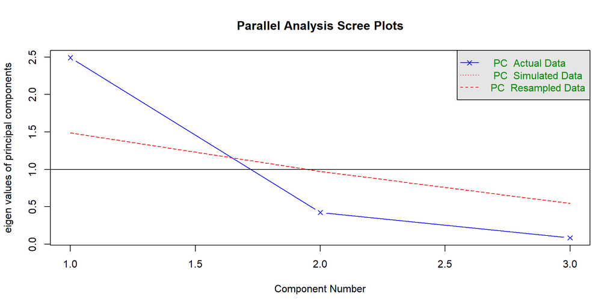

## Voltando ao Exemplo

$$Z_{GB} = \dfrac{\text{Ganho Bruto} - \overline{\text{Ganho Bruto}}}{s_{\text{Ganho Bruto}}}$$

$$Z_{GL} = \dfrac{\text{Ganho Líquido} - \overline{\text{Ganho Líquido}}}{s_{\text{Ganho Líquido}}}$$

$$Z_{PA} = \dfrac{\text{Patrimônio} - \overline{\text{Patrimônio}}}{s_{\text{Patrimônio}}}$$

## Voltando ao Exemplo

$$Y_1 = 0,617 \times Z_{GB} + 0,557 \times Z_{GL} + 0,556 \times Z_{PA} \Longrightarrow
83,08\% \text{ da informação total de } \boldsymbol{z}$$

- **Interpretação:** É basicamente um índice de desempenho global da empresa. O coeficiente de maior grandeza numérica desta componente é relativo a ganho bruto enquanto que os demais coeficientes são aproximadamente iguais. Quanto maior os valores de ganhos brutos e líquido e patrimônio da empresa, maior será o valor numérico da componente. Além disso, todas as três variáveis possui alta correlação com essa componente, indicando serem importantes na composição da mesma.

## Voltando ao Exemplo

$$Y_2 = -0,001 \times Z_{GB} - 0,706 \times Z_{GL} + 0,708 \times Z_{PA} \Longrightarrow
14,12\% \text{ da informação total de } \boldsymbol{z}$$

- **Interpretação:** É uma comparação entre as variáveis ganho líquido e patrimônio, sendo que essas duas variáveis possuem igual importância na composição da mesma. Valores próximos de zero dessa componente indicam empresas com um certo equilíbrio entre ganho líquido e patrimônio acumulado no período.

## Voltando ao Exemplo

```r
fviz_pca_biplot(acp_R, repel = TRUE,
                col.var = "#2E9FDF", # Variables color
                col.ind = "#696969"  # Individuals color
                )
```

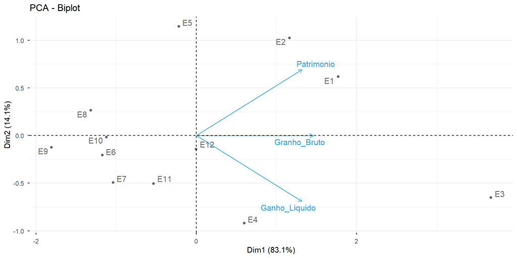

## Voltando ao Exemplo

**Interpretação do biplot**

- As setas indicam em que direção a variável aumenta. os indivíduos que estão posicionados no sentido da seta são os que têm valores maiores naquela variável.
- **Ângulo entre a seta (variável) e o eixo PC1:** O cosseno do ângulo entre a variável e a PC é exatamente o **loading**.

$$\cos(\theta_j, PC_i) = \text{loading}_{X_j, PC_i}$$

## Voltando ao Exemplo

então:

- se a seta está quase colada no eixo $PC_i$
  - loading próximo de +1 → variável altamente alinhada com a componente
  - é variável que define o componente principal
- se a seta faz um ângulo grande (perto de 90°) com $PC_i$
  - loading $\approx 0$ → essa variável não contribui para a componente
- se a seta aponta para o lado oposto da $PC_i$ (180°)
  - loading $\approx -1$ → variável altamente alinhada negativamente

## Voltando ao Exemplo

- **PC1 (Dim1 = 83.1%):** Praticamente toda a informação relevante está aqui.

## Voltando a Exemplo

```r
# Contribuições das variáveis para a PC1
fviz_contrib(acp_R, choice = "var", axes = 1)
```

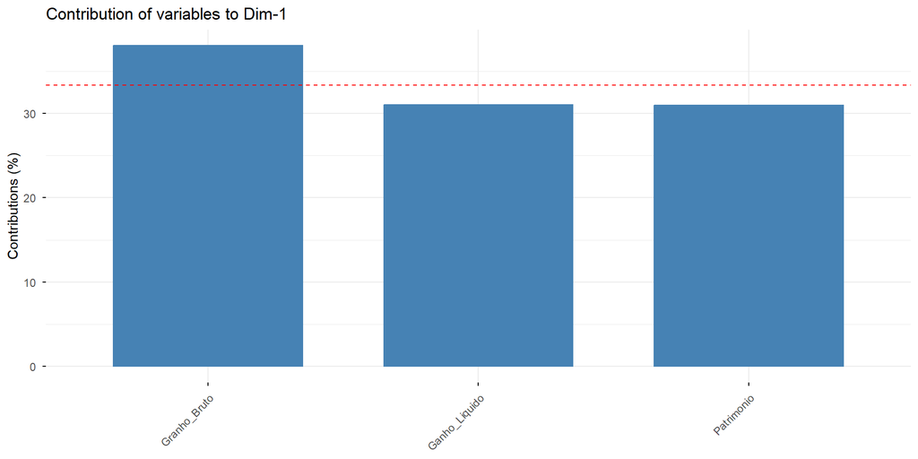

## Voltando ao Exemplo

- Esse gráfico mostra o quanto cada variável explica/contribui para a formação do primeiro componente principal.
  - Ganho Bruto contribuiu um pouco mais
  - Ganho Liquido e Patrimonio contribuem praticamente igual e muito próximo
- A linha vermelha tracejada é a contribuição média esperada (se todas contribuíssem igual).
  - Como temos 3 variáveis → contribuição média = $100\%/3 \approx 33.33\%$

## Voltando ao Exemplo

```r
fviz_contrib(acp_R, choice = "ind", axes = 1:2)
```

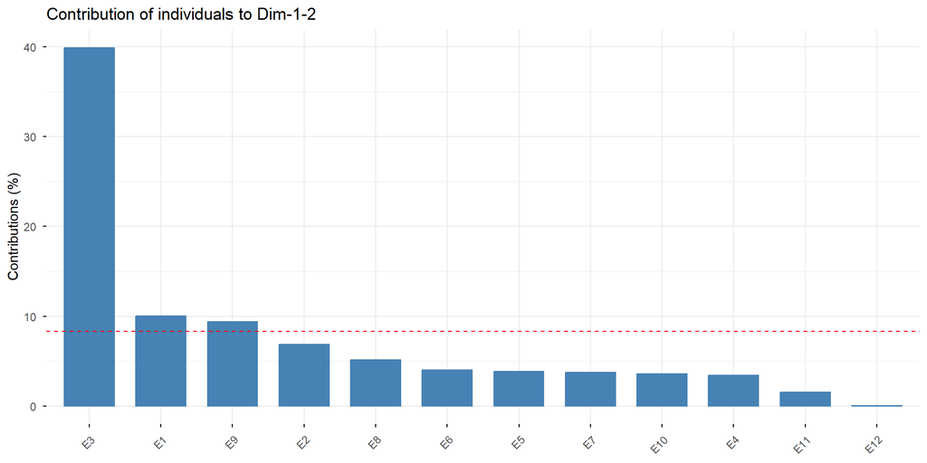

## Voltando ao Exemplo

- Esse gráfico mostra quais indivíduos contribuem mais para definir o plano principal da PC, isto é, quais observações estão orientando a direção das componentes principais.
- A empresa E3 é a maior influenciadora da PCA: sua contribuição para o plano principal é muito superior à média (linha vermelha), indicando que ela é um caso extremo na direção da primeira componente. Esse ponto está orientando de forma dominante a estrutura da análise.